# Is There Just No Pleasing Some People?:

## Categories, Feedback and How They Relate to Pleasure

### Introduction

There are categories of businesses in the *[Yelp! dataset](http://www.yelp.com/dataset_challenge)* that may very well transcend the quality of the businesses within them. The businesses within some categories enjoy, on average, very high ratings from Yelp! reviewers. Nevertheless, there are individuals who have assigned to businesses within one of these **pleasuring categories** at least one review that is at least 1.5 stars lower than the category’s average rating. These people will heretofore be known as the **the miserables**. The inverse is also true: there are those who have assigned at least one rating at least 1.5 stars higher than the average category rating for a business in an **under-pleasuring** category. They will be referred to as **the joyous**.

My hypothesis is that **the joyous** are comprised of folks who receive more compliments from their peers, those being other Yelp! reviewers. And their counterparts, **the miserables** attract fewer compliments from other Yelp! reviewers. And that, furthermore, there is a correlation between how much positive feedback one receives and the likelihood he or she will enjoy a business in Yelp!, no matter how negative or positive a business’s category is found to be.

### Methods

Due to the sheer size of the Yelp! dataset, it was helpful to first move all the data (user, business, review, etc.) into a PostgreSQL database. It made aggregating 1.6 million reviews and over 310,000 users much more practical.

#### Preparing the data

Because each business has multiple categories associated with them, I chose to concatenate all the categories for a business into one string, or **category combination**. And to find out which of these combinations are the **most and least pleasuring**, I only considered those category combinations with at least six businesses associated with them and at least 30 reviews shared among their businesses.

#### The Joyous vs. The Miserables vs. Statistical Inference

Next I wanted to see if there is a difference in the feedback **the joyous** and **the miserables** receive. I performed a sampling distribution of the sample means of hot compliments, funny compliments, total feedback (sum of compliment counts, friends and fans) and the number of reviews written for each of three populations – the joyous, the miserables and the entire population of Yelp! reviewers. I took 2000 samples 100000 times from each population.

As can be seen in *Figure 3*, **the joyous** enjoy more hot compliments, funny compliments and total feedback than **the miserables**, who receive fewer compliments and total feedback than even the average Yelp! reviewer. However, they write, on average, only slightly fewer reviews than the joyous do and well more than the average Yelp! reviewer does.

So given that **the joyous** and **the miserables** differ so much in terms of how they are perceived by the Yelp! community, I decide to assign each Yelp! dataset reviewer to a **feedback group** based on the summary below. **Group 1** reviewers are those who have received between 0 and 2 items of total feedback; whereas, people in **Group 4** have received between 42 and 229400 items of total feedback. Again, the hypothesis here, as extrapolated from the discovery of how **the joyous** are complimented so much more, is that the **Group 4** people will review businesses in **pleasuring** and **under-pleasuring** categories better than their **Group 1** counterparts.

```r
summary(feedb$feedback)
```

```
##     Min.  1st Qu.   Median     Mean  3rd Qu.     Max.
##      0.0      2.0     10.0    153.4     42.0 229400.0
```

#### Natural Language Processing

So, to finally see how the category stem words interplayed with the perception of a reviewer among his or her peers, I created a term matrix for each category combination and then merged that matrix with a data set of average star ratings for each category according to what feedback group the reviewer falls in.

#### Linear Regression

The natural choice seemed to be to take the most **pleasuring** category word, *hair*, and the most **under-pleauring**, *restaurant*, and see how interacting with **feedback group** related to the average rating of a business. Please kindly refer to *Figure 5*.

### Results

**Top 3 most pleasing category combinations**:

```
## [1] "Photographers | Event Planning & Services | Event Photography"
## [2] "Skin Care | Day Spas | Hair Removal | Beauty & Spas"
## [3] "Professional Services | Counseling & Mental Health | Health & Medical | Life Coach"
```

**Top 3 least pleasing category combinations**:

```
## [1] "Professional Services | Home Services | Internet Service Providers"
## [2] "Food | Discount Store | Grocery | Shopping | Drugstores"
## [3] "Dermatologists | Doctors | Health & Medical | Skin Care | Beauty & Spas"
```

The red droplines in the figures below denote the sampled mean for the joyous. Blue for the miserables. And green for the entire population of Yelp! reviewers.

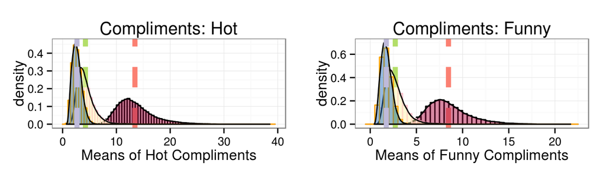

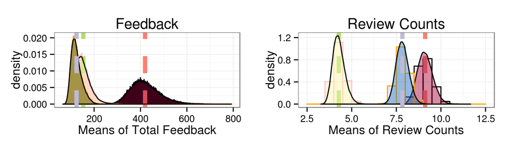

Here are some examples of words more commonly found in **pleasuring** categories than **under-pleasuring** categories. Not surprisingly, these words are somewhat affirming – active, life, beauty.

```
##   joy misery diff  pct.diff  names
## 1  45      5   40 0.8000000   hair
## 2  57     19   38 0.5000000   spas
## 3  51     21   30 0.4166667 beauti
## 4  48     22   26 0.3714286    pet
## 5  32      8   24 0.6000000   life
## 6  30      8   22 0.5789474  activ
```

Words more likely to appear in **under-pleasuring** categories of businesses can be found below:

```
##   joy misery diff   pct.diff    names
## 1  64    213 -149 -0.5379061  restaur
## 2  18    100  -82 -0.6949153      bar
## 3  11     68  -57 -0.7215190 nightlif
## 4  13     62  -49 -0.6533333 american
## 5   5     44  -39 -0.7959184   tradit
## 6  13     44  -31 -0.5438596    store
```

```
##                         Estimate     Pr(>|t|)
## (Intercept)           3.80718352 0.000000e+00
## hair                  0.32702196 8.271441e-19
## feedback_group4       0.05255489 2.656527e-03
## hair:feedback_group4 -0.15969193 2.591978e-03
```

So the results of the linear regression were surprising. Basically what they tell us is that if a group of people in the highest feedback group were to go to a place that is not in a **hair** category (zero mentions of hair in the business category combination), the model expects that on average they would give the business a rating of **3.86**. A group from feedback group 1 would on average rate the business a **3.807**. But what’s surprising is that were these same two groups to enter a **hair** business, with every mention of the word **hair** in the category combination for this business, the model predicts the average rating for the group 4 people will rise **0.16** stars **LESS** than the group 1 people. Please refer to the figure below.

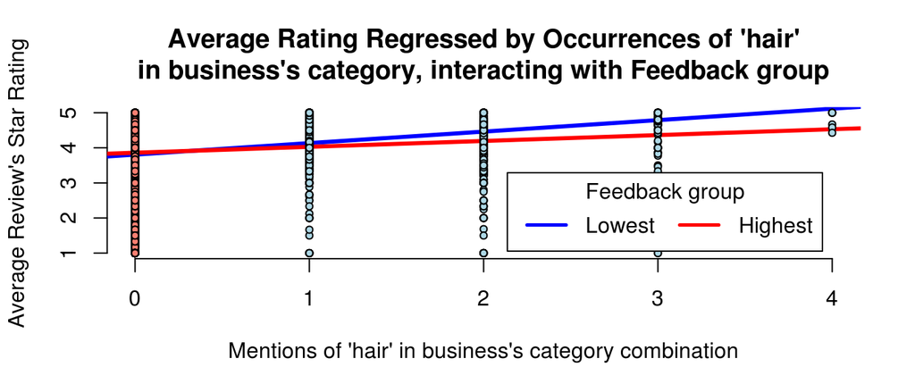

And it’s even worse for the most **unpleasurable** business category word **restaurant**.

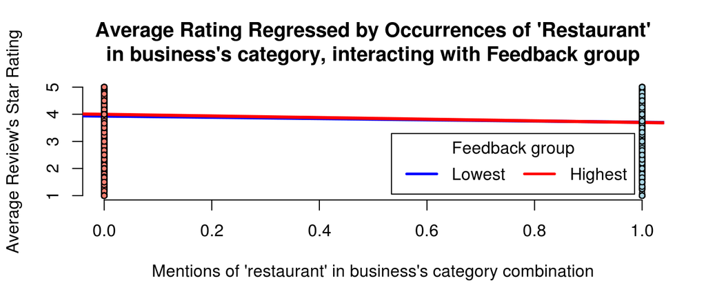

For every instance of the word **restaurant** in a business category, the average star rating or a person in group 4 **actually decreases by 0.301 stars**.

This is not what I was expecting.

### Discussion

When I initially began this project, my goal was to create a model that might spit out a combination of categories statistically shown to elicit the highest user ratings in the hopes that that category combination would be something absurd like **Bail Bonds | Event Planning | Archery Wholesaler**. When that seemed beyond my reach, I decided to investigate what kind of people disliked businesses in the **pleasuring** categories to show that they are miserable no matter what. And that people who get a lot of positive attention – the hot, the funny, the useful – will have a good time no matter where they go, since people may very well fawn on them – for their looks, sense of humor and usefulness.

**Where I went wrong in all this**: extrapolating that a user’s feedback group would denote one’s membership in the joyous or the miserables clan was a mistake. if you look at the histograms below you will see that **FAR AND AWAY**, the mode of both populations for total feedback is ZERO. So, clearly, feedback **Group 1** actually had more of the joyous than it did **miserables**. So the delineation was flawed. **Miserably so**.

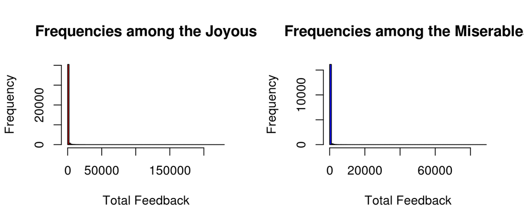